# Logistic Regression

Anasatasia Masalova

04 02 2019

```r
#install.packages("tidyverse")
#install.packages("sjPlot")
#install.packages("pander")
#install.packages("pROC")
#install.packages("car")

library(haven)
library(car)
library(pROC)
library(pander)
library(sjPlot)
library(psych)
library(pscl)
library(margins)
library(generalhoslem)
library(caret)
```

```r
df <- read_spss("ESS6RU.sav")
df1 <- df[, c(60, 163, 278, 302, 358:359, 365:368, 418:423)]
df.my<-df1[,c(1,2,4,10)]
library(tidyverse)
df.my %>% map_chr(~attributes(.)$label)
```

```
##                                                    clsprty
## "Feel closer to a particular party than all other parties"
##                                                     rlgdgr
##                                    "How religious are you"
##                                                       agea
##                            "Age of respondent, calculated"
##                                                     eisced
##                   "Highest level of education, ES - ISCED"
```

Data preparation

```r
df.my$clsprty <- str_replace(df.my$clsprty, "2", "0")
df.my$clsprty <- factor(df.my$clsprty)
df.my$agea <- as.integer(df.my$agea)
df.my$rlgdgr <- as.integer(df.my$rlgdgr)

df.my$eisced <- factor(df.my$eisced)
df.my$eisced <- str_replace(df.my$eisced, "6", "7") #recod 6 (that means Bachelor degree) to 7 (that means MA or higher degree), because 6 has not so many observations. Despite their number is bigger than 5, I suppose, that it can make sense, because in Russia bachelor degree became popular not so many time ago, so not so many respondents can have it.


df.my$eisced = ifelse(df.my$eisced == 4, 3, df.my$eisced)
df.my$eisced = ifelse(df.my$eisced == 5, 4, df.my$eisced)
df.my$eisced = ifelse(df.my$eisced == 7, 5, df.my$eisced)

xtabs(~ clsprty + eisced, data = df.my)
```

```
##        eisced
## clsprty   1   2   3   4   5
##       0  41 114 297 405 400
##       1  29  87 229 346 339
```

```r
df.my<-na.omit(df.my)
```

1) the research question

Can age, religiosity and level of education predict whether or not person has closeness to particular political party?

2) model equation

log[p(Feel closer to a particular party)/p(1-Feel closer to a particular party)] = b0 + b1*Age + b2*Religiosity + b3*Level_of_education

3) scale types

Dependent: **clsprty (nominal, binary)** “Есть ли такая политическая партия, которая Вам ближе, чем все остальные партии? (1) Да (2) Нет”

*** Here it will be: (1) Yes (0) No

Independent: **agea (numeric)** - Age of respondent

**rlgdgr (percepted as numeric here, but in fact can be ordinal too)** - Level of religiosity of respondent. How religious are you? (0) Not at all religious (10) Very religious

**eisced (ordinal)** - Highest level of education (1) less than lower secondary (2) lower secondary (3) upper tier upper secondary (4) advanced vocational, sub-degree (5) BA level + >= MA level

Descriptive statistics for the variables

```r
describe(df.my)
```

```
##          vars    n  mean    sd median trimmed   mad min max range  skew
## clsprty*    1 2236  1.45  0.50      1    1.44  0.00   1   2     1  0.20
## rlgdgr      2 2236  4.47  2.77      5    4.47  2.97   0  10    10 -0.06
## agea        3 2236 45.85 18.01     45   45.30 22.24  15  90    75  0.19
## eisced*     4 2236  3.83  1.07      4    3.95  1.48   1   5     4 -0.67
##          kurtosis   se
## clsprty*    -1.96 0.01
## rlgdgr      -0.88 0.06
## agea        -0.97 0.38
## eisced*     -0.25 0.02
```

```r
#45% of all respondents have preference on one particular political party
#mean age of respondents is 45.85 years (minimum is 15 years and maximum is 90 years)
#distribution of age variable is slightly skewed to the right (skew=0.19)
```

4) model summary

```r
mylogit_mod1 <- glm(clsprty ~ agea + rlgdgr + eisced , data = df.my, family = "binomial")
summary(mylogit_mod1)
```

```
##
## Call:
## glm(formula = clsprty ~ agea + rlgdgr + eisced, family = "binomial",
##     data = df.my)
##
## Deviance Residuals:
##     Min       1Q   Median       3Q      Max
## -1.6803  -1.0646  -0.8213   1.1794   1.8681
##
## Coefficients:
##              Estimate Std. Error z value Pr(>|z|)
## (Intercept) -2.517260   0.326390  -7.712 1.23e-14 ***
## agea         0.025379   0.002604   9.746  < 2e-16 ***
## rlgdgr       0.063487   0.015938   3.983 6.80e-05 ***
## eisced2      0.712795   0.300858   2.369 0.017826 *
## eisced3      0.864697   0.279585   3.093 0.001983 **
## eisced4      0.875421   0.272509   3.212 0.001316 **
## eisced5      0.959025   0.275254   3.484 0.000494 ***
## ---
## Signif. codes:  0 '***' 0.001 '**' 0.01 '*' 0.05 '.' 0.1 ' ' 1
##
## (Dispersion parameter for binomial family taken to be 1)
##
##     Null deviance: 3077.7  on 2235  degrees of freedom
## Residual deviance: 2955.0  on 2229  degrees of freedom
## AIC: 2969
##
## Number of Fisher Scoring iterations: 4
```

And summary in the table

```r
pander(summary(mylogit_mod1))
```

|  | Estimate | Std. Error | z value | Pr(>\|z\|) |
| --- | --- | --- | --- | --- |
| **(Intercept)** | -2.517 | 0.3264 | -7.712 | 1.234e-14 |
| **agea** | 0.02538 | 0.002604 | 9.746 | 1.924e-22 |
| **rlgdgr** | 0.06349 | 0.01594 | 3.983 | 6.796e-05 |
| **eisced2** | 0.7128 | 0.3009 | 2.369 | 0.01783 |
| **eisced3** | 0.8647 | 0.2796 | 3.093 | 0.001983 |
| **eisced4** | 0.8754 | 0.2725 | 3.212 | 0.001316 |
| **eisced5** | 0.959 | 0.2753 | 3.484 | 0.0004937 |

(Dispersion parameter for binomial family taken to be 1 )

| Null deviance: | 3078 on 2235 degrees of freedom |
| --- | --- |
| Residual deviance: | 2955 on 2229 degrees of freedom |

Anova for model comparison

```r
anova(mylogit_mod1, test="Chisq")
```

```
## Analysis of Deviance Table
##
## Model: binomial, link: logit
##
## Response: clsprty
##
## Terms added sequentially (first to last)
##
##
##        Df Deviance Resid. Df Resid. Dev  Pr(>Chi)
## NULL                    2235     3077.7
## agea    1   93.805      2234     2983.9 < 2.2e-16 ***
## rlgdgr  1   15.605      2233     2968.3 7.805e-05 ***
## eisced  4   13.284      2229     2955.0  0.009969 **
## ---
## Signif. codes:  0 '***' 0.001 '**' 0.01 '*' 0.05 '.' 0.1 ' ' 1
```

```r
#model with all 3 predictors is better than model with 0, 1 or 2 predictors
```

5) odds ratios with confidence intervals and predicted probabilities or marginal effects

```r
exp(cbind(OR = coef(mylogit_mod1), confint(mylogit_mod1)))
```

```
##                     OR      2.5 %    97.5 %
## (Intercept) 0.08068037 0.04223306 0.1521445
## agea        1.02570369 1.02051316 1.0309872
## rlgdgr      1.06554520 1.03284765 1.0994567
## eisced2     2.03968401 1.13479512 3.7014505
## eisced3     2.37428649 1.37806802 4.1373582
## eisced4     2.39988581 1.41240998 4.1255138
## eisced5     2.60915051 1.52746461 4.5093443
```

Table with odds ratios and CI

```r
tab_model(mylogit_mod1)
```

|  | clsprty |  |  |
| --- | --- | --- | --- |
| Predictors | Odds Ratios | CI | p |
| (Intercept) | 0.08 | 0.04 – 0.15 | **<0.001** |
| agea | 1.03 | 1.02 – 1.03 | **<0.001** |
| rlgdgr | 1.07 | 1.03 – 1.10 | **<0.001** |
| eisced2 | 2.04 | 1.13 – 3.68 | **0.018** |
| eisced3 | 2.37 | 1.37 – 4.11 | **0.002** |
| eisced4 | 2.40 | 1.41 – 4.09 | **0.001** |
| eisced5 | 2.61 | 1.52 – 4.48 | **<0.001** |
| Observations | 2236 |  |  |
| Cox & Snell’s R<sup>2</sup> / Nagelkerke’s R<sup>2</sup> | 0.053 / 0.071 |  |  |

Predicted probabilities

```r
newdata <- with(df.my, data.frame(agea = mean(agea),
                        rlgdgr = mean(rlgdgr),
                        eisced = factor(1:5)))

newdata$eiscedP <- predict(mylogit_mod1, newdata = newdata, type = "response")

newdata
```

```
##       agea  rlgdgr eisced   eiscedP
## 1 45.85286 4.47093      1 0.2554563
## 2 45.85286 4.47093      2 0.4117040
## 3 45.85286 4.47093      3 0.4489229
## 4 45.85286 4.47093      4 0.4515774
## 5 45.85286 4.47093      5 0.4723543
```

```r
#PP increases with increasing of respondent's level of education
```

```r
newdata2 <- with(df.my, data.frame(agea = rep(seq(from = 15, to = 90, length.out = 100), 5), rlgdgr = mean(rlgdgr), eisced = factor(rep(1:5, each = 100))))
newdata3 <- cbind(newdata2, predict(mylogit_mod1, newdata = newdata2, type = "link", se = T))

newdata3 <- within(newdata3, {
  PredictedProb <- plogis(fit)
  LL <- plogis(fit - (1.96 * se.fit))
  UL <- plogis(fit + (1.96 * se.fit))
})
head(newdata3)
```

```
##       agea  rlgdgr eisced       fit    se.fit residual.scale        UL
## 1 15.00000 4.47093      1 -1.852732 0.2955754              1 0.2186750
## 2 15.75758 4.47093      1 -1.833506 0.2945526              1 0.2216317
## 3 16.51515 4.47093      1 -1.814279 0.2935396              1 0.2246202
## 4 17.27273 4.47093      1 -1.795053 0.2925363              1 0.2276406
## 5 18.03030 4.47093      1 -1.775826 0.2915429              1 0.2306930
## 6 18.78788 4.47093      1 -1.756600 0.2905595              1 0.2337774
##           LL PredictedProb
## 1 0.08076040     0.1355524
## 2 0.08235065     0.1378212
## 3 0.08396790     0.1401217
## 4 0.08561243     0.1424543
## 5 0.08728456     0.1448192
## 6 0.08898458     0.1472167
```

Plot

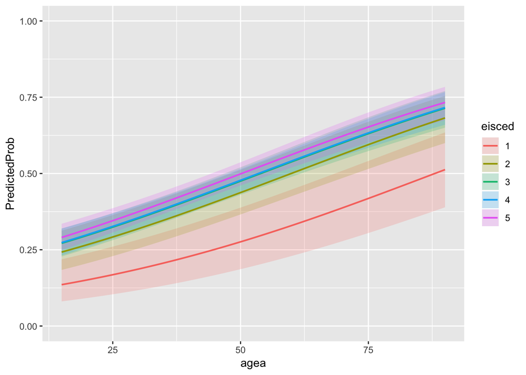

```r
ggplot(newdata3, aes(x = agea, y = PredictedProb)) +
  geom_ribbon(aes(ymin = LL, ymax = UL, fill = eisced), alpha = 0.2)+
  geom_line(aes(colour = eisced), size = 0.75) +
   ylim(0, 1)
```

```r
#The plot shows that predicted probability of being close to particular party increases with age. However, people with less than lower secondary level of education has the lowest probability comparing to other levels of education, which are pretty similar
```